# Creating Scientific Articles with R Markdown

December 03, 2020

## Programs

- MiKTex for Windows, MacTeX for Mac, TeX Live for Linux, (“tinytex”)
- Zotero
- Zotero-Addon in Firefox/Chrome (https://www.zotero.org/download/)

## Package requirements

packages: rticles, tidyverse, citr, knitr, kableExtra

```r
install.packages(
c("rticles","tidyverse","knitr","kableExtra","devtools")
)

devtools::install_github("crsh/citr")
```

```r
library(tidyverse)
library(knitr)
library(kableExtra)
library(rticles)
```

## Why R Markdown?

- Text and code in one document
- Consistency (several reports in same format, templates)
- Reproducibility
- Easy to switch output between PDF, Word, and HTML (and many other formats)
- One R Markdown file for your whole project (data import, cleaning, mergeing, manipulation, calculations,…)
- Large number of extension packages and a big community of R users

## YAML header

YAML: Yet Another Markup Language

What It Is: YAML is a human friendly data serialization standard for programming languages.

Used for configuration files

Example:

```
---
title: "My Paper"
author: "My Name"
abstract: "This is the abstract."
date: "01-01-2020"
output:
  pdf_document:
  keep_tex: TRUE
---
```

## Headers and sections

```r
# Introduction

# Literature review

# Study design

## Data

## Methodology

# Empirical Results

## Sample A

### Sample A-1

### Sample A-2

## Sample B

# Conclusion
```

## Text

- Markdown code  
  `normal text` –> normal text  
  `**bold**` –> **bold**  
  `*italics*` –> *italics*
- LaTex code  
  `\textbf{text}` –>\(\textbf{text}\)  
  `\textit{text}` –>\(\textit{text}\)  
  `\underline{text}` –>\(\underline{text}\)  
  `\textcolor{red}{text}` –>\(\color {red} {text}\)  
  `\newline` –>linebreak  
  `\newpage` –>newpage

## Hyperlinks I

- Hyperlinks to sections

```
---
link-citations: TRUE
header-includes:
  \usepackage{float}
  \usepackage{hyperref}
            \hypersetup{colorlinks=true,linkcolor=blue}
  \AtBeginDocument{
  \hypersetup{pdfborder={0 0 1},linkbordercolor=red}}
---

# Introduction

This paper is divided into four further sections.
The next [section](#literaturereview) provides a brief review of
relevant literature.

\newpage

# Literature review {#literaturereview}
```

## Embed code

- Inline code

The average HP (horse Power) of all cars is `` `r mean(mtcars$hp)` ``.

The average HP (horse Power) of all cars is 146.6875

- Code chunks

````
```{r chunk1, include=T, echo=T}
mean(mtcars$hp)
```
````

```
## [1] 146.6875
```

## Chunk options

```
eval=TRUE,
include=TRUE,
echo=TRUE,
error=TRUE,
message=TRUE,
warning=TRUE,
```

More information:

https://rstudio.com/wp-content/uploads/2015/03/rmarkdown-reference.pdf

## Figures

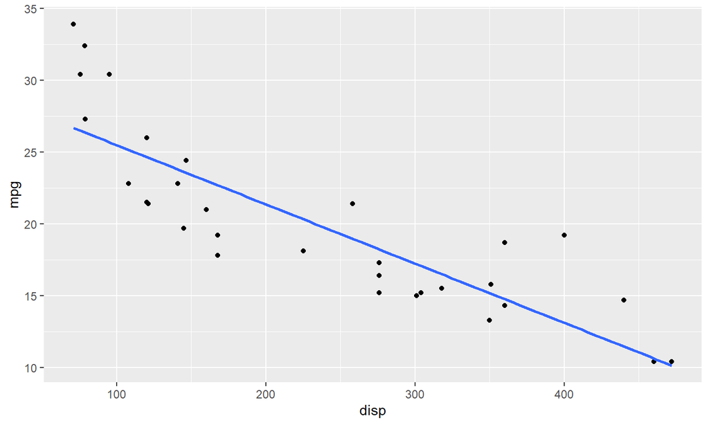

Relationship between disp and mpg

```r
mtcars%>%
  ggplot(aes(x=disp,y=mpg))+
  geom_point()+
  geom_smooth(method = "lm",se = F)
```

## Figures II

- Chunk options

````
```
{r chunk_name, message=FALSE, echo=TRUE,
fig.cap= "figure caption",
fig.align="center",
fig.height=5,
fig.width=7,
out.height = "70%",
out.width = "70%"
}
```
````

## Tables

```
mtcars%>%
  head(5)%>%
  kable(booktabs = T, caption="Table mtcars")%>%
  kable_styling(
    latex_options = c("hold_position"),
    position = "center",
    full_width = T)
```

Literature: https://haozhu233.github.io/kableExtra/awesome_table_in_pdf.pdf

## Hyperlinks II

- Chunk label must be named!
- Hyperlinks to figures

`\hyperref[fig:figure_1]{Figure~\ref*{fig:figure_1}}`

- Hyperlinks to tables

`\hyperref[tab:table_1]{Table~\ref*{tab:table_1}}`

## Collect literature with Zotero

- Create new bibliography file in Zotero
- Collect literature with Zotero Connector (Browser Addon)
- Export Zotero bibliography in the working directory

```
# References {-}
<div id="refs"></div>
```

## Insert citations

- Search citation style: https://www.zotero.org/styles
- Download CSL (Citation Style Language) in the working directory

```
---
bibliography: references.bib
csl: journal-of-banking-and-finance.csl
---
```

- Start the `CITR`-Addin

## Hyperlinks III

### Hyperlinks to citations:

```
---
header-includes:
  \usepackage{hyperref}
    \hypersetup{urlcolor=green}

  \AtBeginDocument{
    \hypersetup{urlbordercolor=red}
  }
---
```

- see more:

https://de.wikibooks.org/wiki/LaTeX-W%C3%B6rterbuch:_hyperref

## Templates

- Creating submission-ready documents
- Package `rticles` provides templates for various journals and publishers, for example:
  - Elsevier journal submissions
  - Springer journal submissions
- Choose `rticles`-templates in the settings of a new markdown document

## Outlook and further Information

Visual editor in RStudio 1.4:

- https://rstudio.com/products/rstudio/download/preview/

Literature:

- https://bookdown.org/yihui/rmarkdown/
- https://bookdown.org/yihui/rmarkdown-cookbook/
- https://rmarkdown.rstudio.com/